# Inspect Different Length Sample Size impact on ISS 1.0

Brett Stacy

IGNORE THIS SCRIPT!! THE RESULTS ARE INVALID! I DID NOT CODE THE SUBSAMPLING CORRECTLY, I DID NOT USE SIZE ARGUEMENT IN SAMPLE.INT LIKE I SHOULD HAVE. WHEN I TRIED TO USE IT, BOOT_LENGTH WOULD NOT WORK BECAUSE MUTATE CANNOT ACCEPT UNEQUAL LENGTH VECTORS TO WHAT IT IS ASKED TO REPLACE.

# Data Generated With:

C:/Users/bstacy2/OneDrive - UW/UW Postdoc/GitHub Repos/baseISS/run/run_ISS_0.5.1.R

# Introduction

Plot the ISS resulting from three levels of haul-level sample size: 1. min(.N, 10) 2. .N 3. min(.N, 30)

ancillary details: - sample WR - years 1999-2023 (median = 20 fish per haul) - fixed values, not proportions

## Compare

Plot

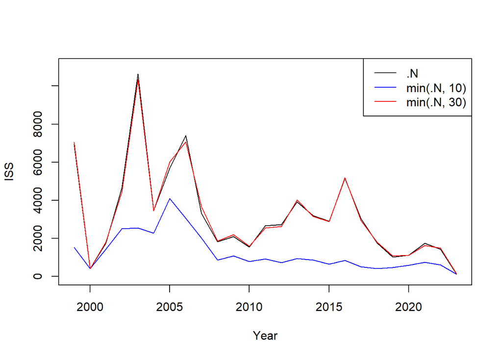

Stats

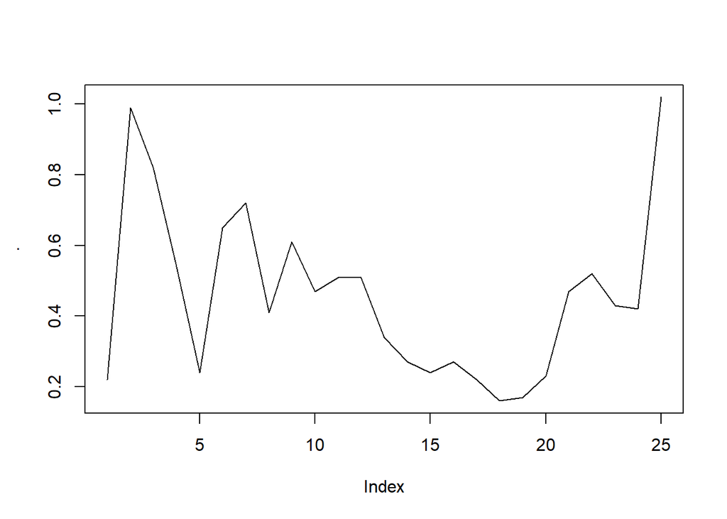

```
## [1] 0.458
```

# Conclusion

.N and 30 were equivalent. 10 was an average of 46% of .N, so about half. Implying uncertainty decreases proportional to sample size.

Try a more advanced option for changing length N where a separate sample function is called as a condition in boot_length.

UPDATE: THIS OUTPUT IS INNACURATE! I DID NOT CODE THE SAMPLING ROUTINE CORRECTLY: IT DOES NOT SUBSAMPLE, RATHER IT TAKES .N IN BOTH CASES WHEN I INTENDED OTHERWISE.